# Yu-Gi-Oh

Yu-Gi-Oh the card game, the game of strategy, mind tricks, spells and traps.

*Data Source* - [Yu-Gi-Oh! Cards](https://www.kaggle.com/ioexception/yugioh-cards?select=cards.csv)

# 1 - Preping our enviornment

Starting off we want to prep our work area with the libraries we want to use and the data that we will be using.

### 1.1 - Setting up tidyverse

```r
library(tidyverse)
```

### 1.2 - Getting our data

```r
data <- read.csv('cards.csv')
head(data)
```

|  | id | name | type | desc | atk | def | level | race | attribute | scale | archetype | linkval | linkmarkers | image_url | image_url_small | ban_tcg | ban_ocg | ban_goat |
| --- | --- | --- | --- | --- | --- | --- | --- | --- | --- | --- | --- | --- | --- | --- | --- | --- | --- | --- |
| 1 | 34541863 | "A" Cell Breeding Device | Spell Card | During each of your Standby Phases, put 1 A-Counter on 1 face-up monster your opponent controls. | NA | NA | NA | Continuous |  | NA | Alien | NA |  | https://storage.googleapis.com/ygoprodeck.com/pics/34541863.jpg | https://storage.googleapis.com/ygoprodeck.com/pics_small/34541863.jpg |  |  |  |
| 2 | 64163367 | "A" Cell Incubator | Spell Card | Each time an A-Counter(s) is removed from play by a card effect, place 1 A-Counter on this card. When this card is destroyed, distribute the A-Counters on this card among face-up monsters. | NA | NA | NA | Continuous |  | NA | Alien | NA |  | https://storage.googleapis.com/ygoprodeck.com/pics/64163367.jpg | https://storage.googleapis.com/ygoprodeck.com/pics_small/64163367.jpg |  |  |  |
| 3 | 91231901 | "A" Cell Recombination Device | Spell Card | Target 1 face-up monster on the field; send 1 "Alien" monster from your Deck to the Graveyard, and if you do, place A-Counters on that monster equal to the Level of the sent monster. During your Main … | NA | NA | NA | Quick-Play |  | NA | Alien | NA |  | https://storage.googleapis.com/ygoprodeck.com/pics/91231901.jpg | https://storage.googleapis.com/ygoprodeck.com/pics_small/91231901.jpg |  |  |  |
| 4 | 73262676 | "A" Cell Scatter Burst | Spell Card | Select 1 face-up "Alien" monster you control. Destroy it and distribute new A-Counters equal to its Level among your opponent's face-up monsters. | NA | NA | NA | Quick-Play |  | NA | Alien | NA |  | https://storage.googleapis.com/ygoprodeck.com/pics/73262676.jpg | https://storage.googleapis.com/ygoprodeck.com/pics_small/73262676.jpg |  |  |  |
| 5 | 37478723 | "Infernoble Arms - Durendal" | Spell Card | While this card is equipped to a monster: You can add 1 Level 5 or lower FIRE Warrior monster from your Deck to your hand, then destroy this card. If this card is sent to the GY because the equipped m… | NA | NA | NA | Equip |  | NA | Noble Knight | NA |  | https://storage.googleapis.com/ygoprodeck.com/pics/37478723.jpg | https://storage.googleapis.com/ygoprodeck.com/pics_small/37478723.jpg |  |  |  |
| 6 | 64867422 | "Infernoble Arms - Hauteclere" | Spell Card | While this card is equipped to a monster: You can target 1 face-up monster you control; this turn, you cannot declare attacks with other monsters, also it can make a second attack during each Battle P… | NA | NA | NA | Equip |  | NA | Noble Knight | NA |  | https://storage.googleapis.com/ygoprodeck.com/pics/64867422.jpg | https://storage.googleapis.com/ygoprodeck.com/pics_small/64867422.jpg |  |  |  |

# 2 - Overview

```r
summary(data)
```

```
       id                name
 Min.   :    10000   Length:11183
 1st Qu.: 24466676   Class :character
 Median : 49511705   Mode  :character
 Mean   : 51356349
 3rd Qu.: 74892018
 Max.   :501000007

     type               desc                atk
 Length:11183       Length:11183       Min.   :   0
 Class :character   Class :character   1st Qu.: 800
 Mode  :character   Mode  :character   Median :1500
                                       Mean   :1464
                                       3rd Qu.:2100
                                       Max.   :5000
                                       NA's   :3797
      def           level            race
 Min.   :   0   Min.   : 0.000   Length:11183
 1st Qu.: 500   1st Qu.: 3.000   Class :character
 Median :1200   Median : 4.000   Mode  :character
 Mean   :1225   Mean   : 4.501
 3rd Qu.:1800   3rd Qu.: 6.000
 Max.   :5000   Max.   :13.000
 NA's   :4126   NA's   :4127
  attribute             scale         archetype
 Length:11183       Min.   : 0.000   Length:11183
 Class :character   1st Qu.: 2.000   Class :character
 Mode  :character   Median : 4.000   Mode  :character
                    Mean   : 4.381
                    3rd Qu.: 7.000
                    Max.   :13.000
                    NA's   :10905
    linkval      linkmarkers         image_url
 Min.   :1.000   Length:11183       Length:11183
 1st Qu.:2.000   Class :character   Class :character
 Median :2.000   Mode  :character   Mode  :character
 Mean   :2.383
 3rd Qu.:3.000
 Max.   :6.000
 NA's   :10854
 image_url_small      ban_tcg
 Length:11183       Length:11183
 Class :character   Class :character
 Mode  :character   Mode  :character




   ban_ocg            ban_goat
 Length:11183       Length:11183
 Class :character   Class :character
 Mode  :character   Mode  :character
```

By just giving our data the glance over we can tell that there are a total of 11,183 cards currently in the TCG and OCG.

- These are the key questions that we want answered
  - Which card has the longest desc, on average how long are card desc?
  - What is the average Atk and Def for each level of monster?

# 3 - Exploring Data

```r
unique(data$type)
```

```
 [1] "Spell Card"
 [2] "Effect Monster"
 [3] "Normal Monster"
 [4] "Flip Effect Monster"
 [5] "Trap Card"
 [6] "Union Effect Monster"
 [7] "Fusion Monster"
 [8] "Pendulum Effect Monster"
 [9] "Link Monster"
[10] "XYZ Monster"
[11] "Synchro Tuner Monster"
[12] "Tuner Monster"
[13] "Synchro Monster"
[14] "Gemini Monster"
[15] "Normal Tuner Monster"
[16] "Spirit Monster"
[17] "Ritual Effect Monster"
[18] "Token"
[19] "Skill Card"
[20] "Ritual Monster"
[21] "Toon Monster"
[22] "Pendulum Normal Monster"
[23] "Synchro Pendulum Effect Monster"
[24] "Pendulum Tuner Effect Monster"
[25] "XYZ Pendulum Effect Monster"
[26] "Pendulum Effect Fusion Monster"
[27] "Pendulum Flip Effect Monster"
```

We can observe that there are 27 different types of cards that are utilized in game.

```r
unique(data$attribute)
```

```
[1] ""       "EARTH"  "WATER"  "WIND"   "DARK"
[6] "LIGHT"  "FIRE"   "DIVINE"
```

Monster cards have these attributes, while other types of cards do not.

```r
data$attribute[data$attribute == ""] <- "NONE"
```

Normally Cards with no attribute will appear as blank for visualization purposes I transformed them into a readable variable.

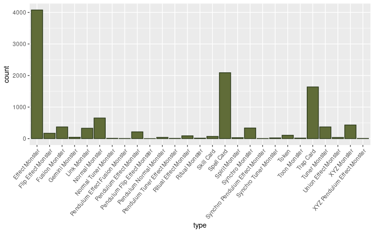

```r
ggplot(data = data) +
  geom_bar(mapping = aes(type), stat = "count", fill='#606c38', colour = '#283618') +
  theme(axis.text.x = element_text(angle = 50, vjust = 1, hjust = 1))
```

Looks like Effect Monsters are the most produced by a large margin, almost double the amount of spell cards which are the second most produced card.

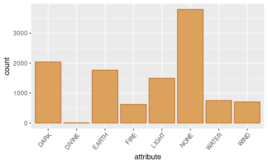

```r
ggplot(data = data) +
  geom_bar(mapping = aes(attribute), stat = "count", fill='#dda15e', colour = '#bc6c25') +
  theme(axis.text.x = element_text(angle = 50, vjust = 1, hjust = 1))
```

The most common attribute (Not counting spells, traps and tokens) in the game is DARK, second EARTH, third LIGHT, the rest are equally not as used in the game and DIVINE is only used in special cards.

# 4 - Answering our questions

### 4.1 - Which card has the longest desc, on average how long are card desc?

```r
data$desc_length <- str_length(str_replace_all(data$desc, " ", ""))
```

Here we want to count each of the characters not including spaces.

```r
mean(data$desc_length)
```

```
[1] 225.0753
```

Each card’s description has an average of 225.07 letters. In the English language words average 4.7 letters in length. This would mean that in general each card has 47.88 words.

```r
subset(data, desc_length == max(desc_length))
```

|  | id | name | type | desc | atk | def | level | race | attribute | scale | archetype | linkval | linkmarkers | image_url | image_url_small | ban_tcg | ban_ocg | ban_goat | desc_length |
| --- | --- | --- | --- | --- | --- | --- | --- | --- | --- | --- | --- | --- | --- | --- | --- | --- | --- | --- | --- |
| 3165 | 3611830 | Endymion, the Mighty Master of Magic | Pendulum Effect Monster | [ Pendulum Effect ]\nYou can remove 6 Spell Counters from your field; Special Summon this card from the Pendulum Zone, then count the number of cards you control that can have a Spell Counter, destroy… | 2800 | 1700 | 7 | Spellcaster | DARK | 8 | Endymion | NA |  | https://storage.googleapis.com/ygoprodeck.com/pics/3611830.jpg | https://storage.googleapis.com/ygoprodeck.com/pics_small/3611830.jpg |  |  |  | 860 |

[figure not shown]

> The Yu-Gi-Oh card with the longest description with 73 for the top portion and 107 for the bottom text adding up to 180 words in total.

### 4.2 - What is the average Atk and Def for each level of monster?

Logically we would assume that depending on the level of the monster the Atk and/or Def would increase.

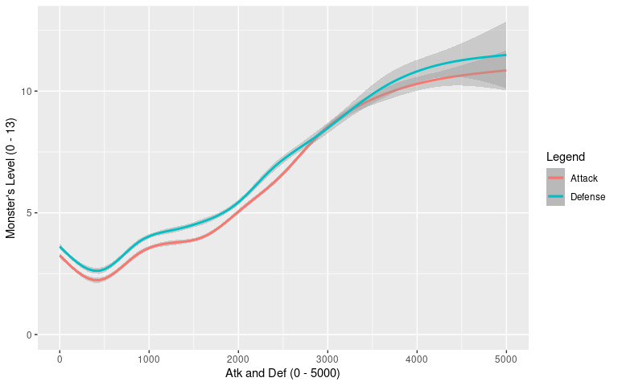

```r
ggplot(data = data, aes(y = level)) +
  geom_smooth(aes(x = atk, colour = "Attack")) +
  geom_smooth(aes(x = def, colour = "Defense")) +
  labs(
    x = "Atk and Def (0 - 5000)",
    y = "Monster's Level (0 - 13)",
    colour = "Legend"
       ) +
  ylim(0, NA)
```

Through this chart we can see that higher levels have generally high Attack and Defense, this would seem obvious but could be a trap that a card game may fall through during many years in their run.

# 5 - What does it mean?

In the end we can see that despite all the years and all the cards created Yu-Gi-Oh has managed to stay balanced with few banned cards here and there.

Though one problem that surged is that due to the increase in effect monsters cards and the fact that on average cards have a lot of words, which could deter newer players from wanting to pick up the game.